# ECON6027_6a

Dr. Liu

## Read neighbours from an existing GAL file

Load the required libraries:

```r
library(sf); library(spdep)
```

Contiguity neighbour GAL file for UK

```r
(UK_nb = read.gal("uk_cont.gal"))
```

```
## Neighbour list object:
## Number of regions: 12
## Number of nonzero links: 42
## Percentage nonzero weights: 29.16667
## Average number of links: 3.5
```

```r
class(UK_nb)
```

```
## [1] "nb"
```

nb is a neighbour list object which is how neighbourhood information is handled in the R ecosystem.

We also need a shapefile to anchor the external “nb” object to…

```r
(UK = st_read("NUTS_Level_1__January_2018__Boundaries.shp"))
```

```
## Simple feature collection with 12 features and 9 fields
## Geometry type: MULTIPOLYGON
## Dimension:     XY
## Bounding box:  xmin: -70.2116 ymin: 7054.2 xmax: 655604.7 ymax: 1220302
## Projected CRS: OSGB36 / British National Grid
## First 10 features:
##    objectid nuts118cd                nuts118nm  bng_e  bng_n      long      lat
## 1         1       UKC     North East (England) 417313 600358 -1.728900 55.29703
## 2         2       UKD     North West (England) 350015 506280 -2.772370 54.44945
## 3         3       UKE Yorkshire and The Humber 446903 448736 -1.287120 53.93264
## 4         4       UKF  East Midlands (England) 477660 322635 -0.849670 52.79572
## 5         5       UKG  West Midlands (England) 386294 295477 -2.203580 52.55697
## 6         6       UKH          East of England 571074 263229  0.504146 52.24067
## 7         7       UKI                   London 517516 178392 -0.308640 51.49227
## 8         8       UKJ     South East (England) 470062 172924 -0.993110 51.45097
## 9         9       UKK     South West (England) 285015 102567 -3.633430 50.81119
## 10       10       UKL                    Wales 263406 242881 -3.994160 52.06741
##     st_areasha st_lengths                       geometry
## 1   8609938893   657578.2 MULTIPOLYGON (((397942.9 65...
## 2  14182609113  1063052.7 MULTIPOLYGON (((357136.2 58...
## 3  15432322860   863264.1 MULTIPOLYGON (((480000 5176...
## 4  15658181358   889656.3 MULTIPOLYGON (((516022.7 41...
## 5  13002149549   774627.1 MULTIPOLYGON (((409403 3657...
## 6  19155125591  1083693.3 MULTIPOLYGON (((599964.1 34...
## 7   1585475935   270855.1 MULTIPOLYGON (((537543.8 19...
## 8  19115903194  1454554.9 MULTIPOLYGON (((493941.1 25...
## 9  23979440241  1647103.7 MULTIPOLYGON (((416007.6 24...
## 10 20820253175  1552749.7 MULTIPOLYGON (((314837 3813...
```

```r
table(st_is_valid(UK)) # all valid
```

```
##
## TRUE
##   12
```

In general, after this step, you need to make sure the areal units are in the same order as the “nb” object. For your convenience, in this case, I have made sure that the object ID of the shapefile and the gal file are the same.

Next, we will plot the contiguity relationships among the regions of UK on a map of UK.

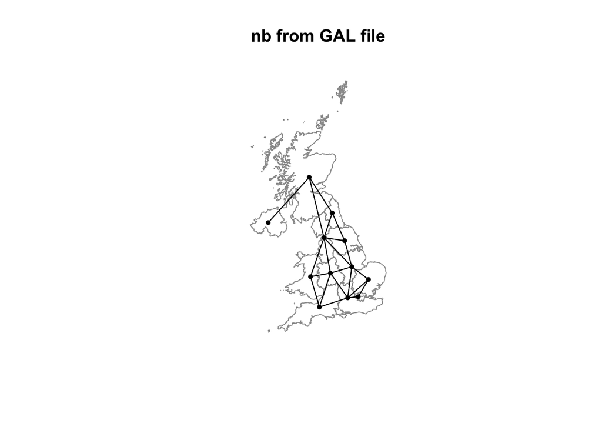

```r
UK_coords = st_point_on_surface(st_geometry(UK))
plot(st_geometry(UK), border="grey60", reset = F, main="nb from GAL file")
plot(UK_nb, UK_coords, pch=19, cex=0.6, add=T)
```

```r
# write.nb.gal(UK_nb, "UK_nb_new.gal", oldstyle=F) # create GAL file
```

See ?plot.nb for more details on plotting nb objects.

## Create neighbours based on spatial polygons

We will work with Singapore planning areas.

```r
SG = st_read("MySingapura.shp")
table(st_is_valid(SG))
```

```
##
## FALSE  TRUE
##     8    47
```

```r
SG = st_make_valid(SG); table(st_is_valid(SG))
```

```
##
## TRUE
##   55
```

### 1. Contiguous neighbours

The poly2nb() function can be used to convert polygon objects to nb objects. The default is queen contiguity neighbours from SG. If we make queen=F, then we get the rook contiguity.

```r
(SG1_nb = poly2nb(SG)) # queen contiguity
```

```
## Neighbour list object:
## Number of regions: 55
## Number of nonzero links: 258
## Percentage nonzero weights: 8.528926
## Average number of links: 4.690909
## 1 region with no links:
## 38
## 2 disjoint connected subgraphs
```

```r
# write.nb.gal(SG1_nb, "SG1_nb.gal", oldstyle=F)
(SG2_nb = poly2nb(SG, queen=F)) # rook contiguity
```

```
## Neighbour list object:
## Number of regions: 55
## Number of nonzero links: 258
## Percentage nonzero weights: 8.528926
## Average number of links: 4.690909
## 1 region with no links:
## 38
## 2 disjoint connected subgraphs
```

```r
# check the snap argument
```

Let us plot the contiguity neighbours on a map of Singapore.

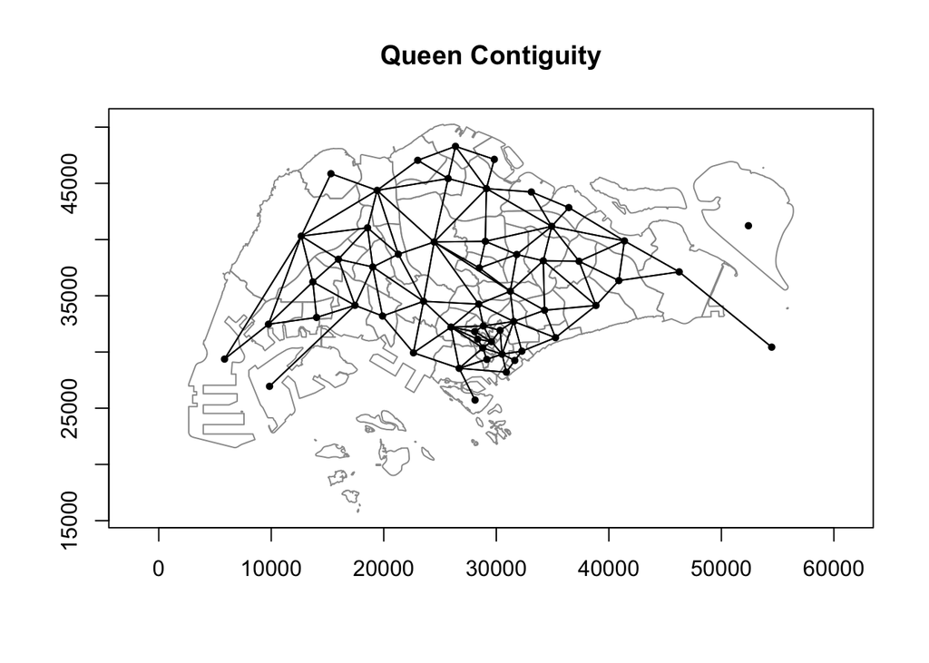

```r
SG_coords = st_point_on_surface(st_geometry(SG))

plot(st_geometry(SG), border="grey60", axes=T,  main="Queen Contiguity")
plot(SG1_nb, SG_coords, pch=19, cex=0.6, add=T)
```

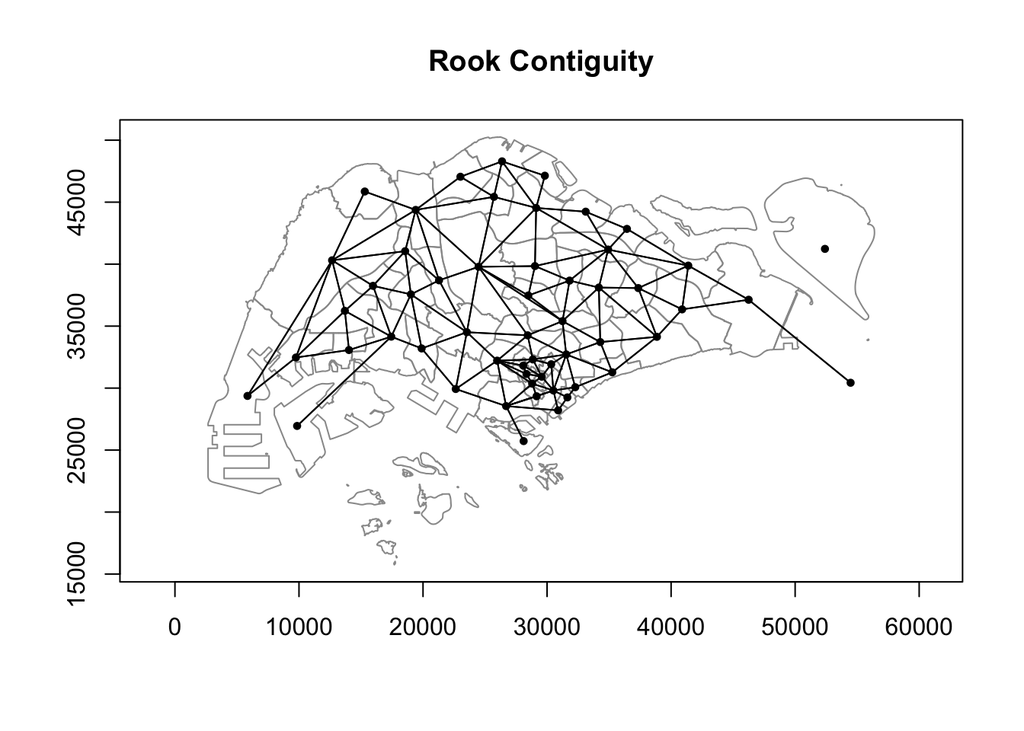

```r
plot(st_geometry(SG), border="grey60", axes=T,  main="Rook Contiguity")
plot(SG2_nb, SG_coords, pch=19, cex=0.6, add=T)
```

```r
isTRUE(all.equal(SG1_nb, SG2_nb, check.attributes = F))
```

```
## [1] TRUE
```

For Singapore planning areas queen contiguity is the same as rook contiguity.

### 2. k nearest neighbours

```r
(IDs = row.names(SG))
```

```
##  [1] "1"  "2"  "3"  "4"  "5"  "6"  "7"  "8"  "9"  "10" "11" "12" "13" "14" "15"
## [16] "16" "17" "18" "19" "20" "21" "22" "23" "24" "25" "26" "27" "28" "29" "30"
## [31] "31" "32" "33" "34" "35" "36" "37" "38" "39" "40" "41" "42" "43" "44" "45"
## [46] "46" "47" "48" "49" "50" "51" "52" "53" "54" "55"
```

```r
SG3_nb = knn2nb(knearneigh(SG_coords, k = 1), row.names = IDs) # nearest neighbour
SG4_nb = knn2nb(knearneigh(SG_coords, k = 2), row.names = IDs) # 2 nearest neighbours
SG5_nb = knn2nb(knearneigh(SG_coords, k = 3), row.names = IDs) # 3 nearest neighbours
```

Note that metric distances may vary if st_centroid is used. Let us plot the k nearest neighbours on a map of Singapore.

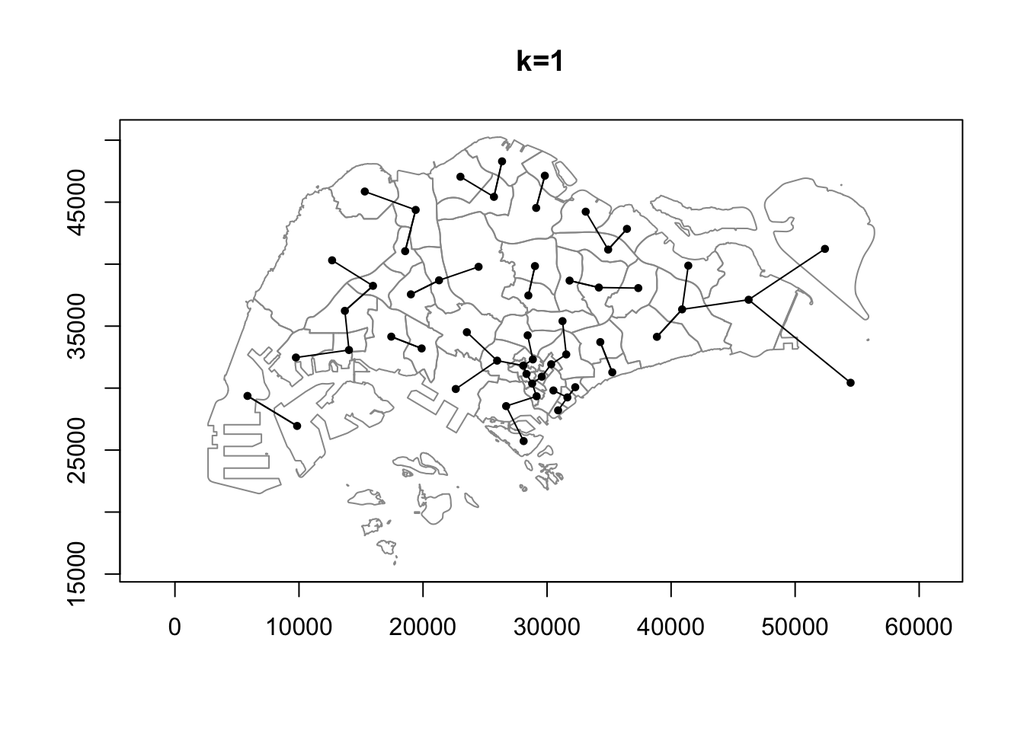

```r
plot(st_geometry(SG), border="grey60", axes=T,  main="k=1")
plot(SG3_nb, SG_coords, pch=19, cex=0.6, add=T)
```

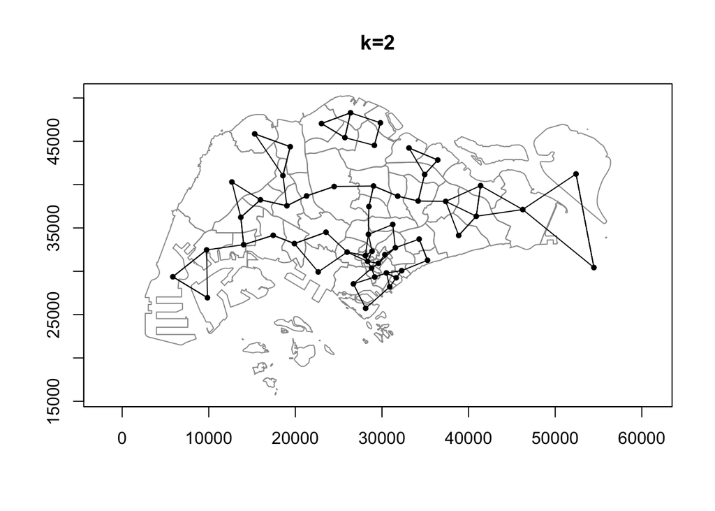

```r
plot(st_geometry(SG), border="grey60", axes=T,  main="k=2")
plot(SG4_nb, SG_coords, pch=19, cex=0.6, add=T)
```

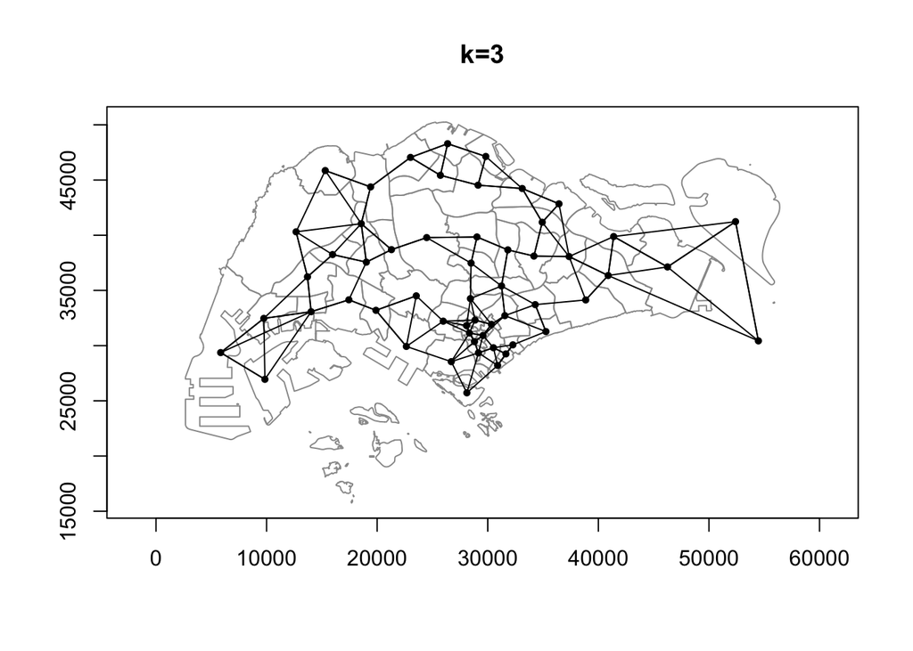

```r
plot(st_geometry(SG), border="grey60", axes=T,  main="k=3")
plot(SG5_nb, SG_coords, pch=19, cex=0.6, add=T)
```

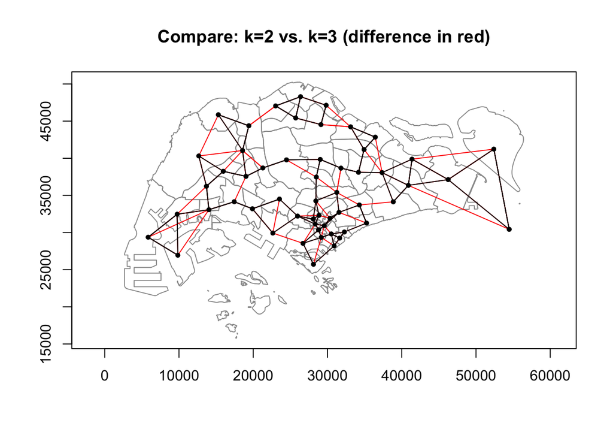

```r
plot(st_geometry(SG), border="grey60", axes=T,  main="Compare: k=2 vs. k=3 (difference in red)")
plot(SG5_nb, SG_coords, col="red", pch=19, cex=0.6, add=T) # plot the nb with more connections first.
plot(SG4_nb, SG_coords, pch=19, cex=0.6, add=T)
```

The final plot shows the difference between the neghbourhood relationships when k=2 and k=3.

### 3. Distance based neighbours

The following chunk create nb objects based on three distances and plots them.

```r
st_crs(SG)$units
```

```
## [1] "m"
```

```r
SG6_nb = dnearneigh(SG_coords, d1 = 0, d2 = 1000, row.names = IDs)
SG7_nb = dnearneigh(SG_coords, d1 = 0, d2 = 5000, row.names = IDs)
SG8_nb = dnearneigh(SG_coords, d1 = 0, d2 = 10000, row.names = IDs)
```

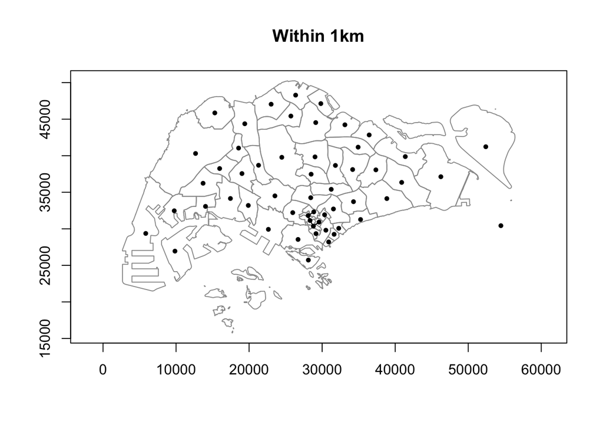

```r
plot(st_geometry(SG), border="grey60", axes=T,  main="Within 1km")
plot(SG6_nb, SG_coords, pch=19, cex=0.6, add=T)
```

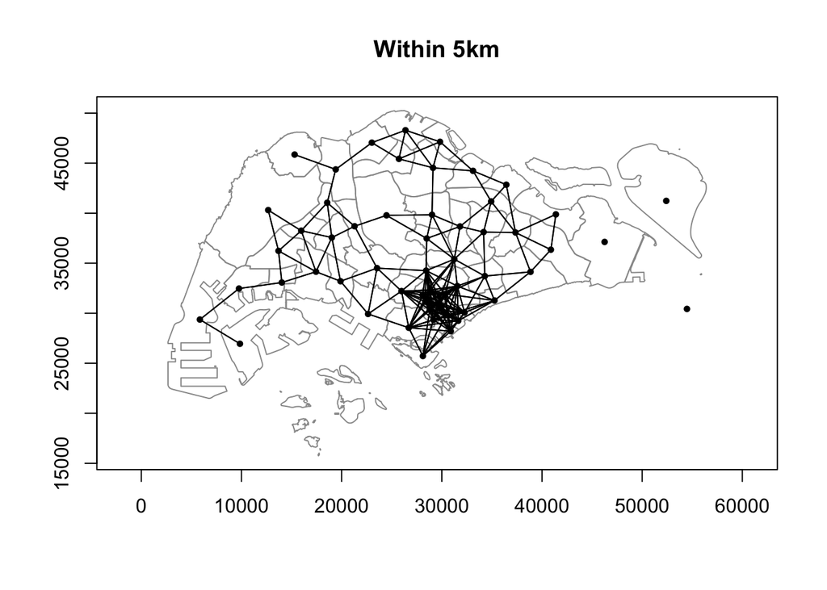

```r
plot(st_geometry(SG), border="grey60", axes=T,  main="Within 5km")
plot(SG7_nb, SG_coords, pch=19, cex=0.6, add=T)
```

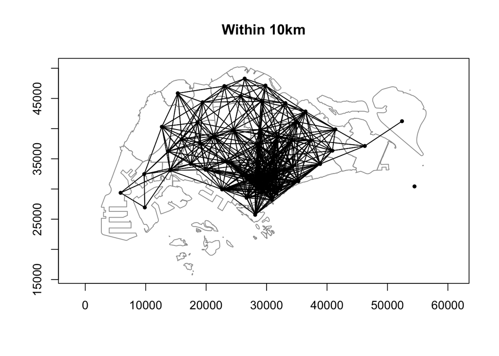

```r
plot(st_geometry(SG), border="grey60", axes=T,  main="Within 10km")
plot(SG8_nb, SG_coords, pch=19, cex=0.6, add=T)
```

As can be seen from the plots, note that distance-based neighbours can leave some spatial units neighbour-less and the degree of connectedness can exponentially increase as you increase the distance.

## Create a weights list object from nb object

The nb list object that we created before contains information on how areal units are related to one another. It must be converted to a weights matrix before it can be used in statistical analyses. We can do this by suing the function nb2listw(). This function converts the nb list to a weights list object that contains information about the type of the weights matrix to be used in the analysis. Example:

```r
(UK_lw = nb2listw(UK_nb)) # row normalised weights
```

```
## Characteristics of weights list object:
## Neighbour list object:
## Number of regions: 12
## Number of nonzero links: 42
## Percentage nonzero weights: 29.16667
## Average number of links: 3.5
##
## Weights style: W
## Weights constants summary:
##    n  nn S0       S1       S2
## W 12 144 12 7.751111 50.16889
```

```r
names(UK_lw)
```

```
## [1] "style"      "neighbours" "weights"
```

```r
names(attributes(UK_lw))
```

```
## [1] "names"       "class"       "region.id"   "call"        "zero.policy"
## [6] "GeoDa"
```

```r
summary(unlist(UK_lw$weights))
```

```
##    Min. 1st Qu.  Median    Mean 3rd Qu.    Max.
##  0.1667  0.2000  0.2667  0.2857  0.3333  1.0000
```

```r
summary(sapply(UK_lw$weights, sum))
```

```
##    Min. 1st Qu.  Median    Mean 3rd Qu.    Max.
##       1       1       1       1       1       1
```

There are many style options (see ?nb2listw). The default is the row normalised form. Row standardising can turn a symmetric weights matrix into an asymmetric one. There is also the chance of boosting the weights of the units near the boundary.

In many econometric applications it is the norm to use style=“W” matrix as it has the property of sum(W)=n which is quite useful in numerical optimisations and other computations related to estimation of parameters and test statistics. (See next chapter).

By default, zero.policy=F, which means there cannot be “loners”. You can disable this by setting zer.policy=T but in many econometric applications such a W matrix raises more problems than can be answered, for example, the effective sample size, a.k.a degrees of freedom in tests model identification issues, etc. Example:

```r
# (SG1_lw = nb2listw(SG1_nb))
# (SG1_lw = nb2listw(SG1_nb, zero.policy=T))
# print(SG1_lw, zero.policy=T)
```